# Lecture 4: QR Decomposition

Author

Joong-Ho Won

Published

April 2026

**Code Output**

```r
library(Matrix)
```

## QR Decomposition

- We learned Cholesky decomposition as **one** approach for solving linear regression.
- Another approach for linear regression uses the QR decomposition.  
  **This is how the `lm()` function in R does linear regression.**

```r
set.seed(2020) # seed

n <- 5
p <- 3
(X <- matrix(rnorm(n * p), nrow=n)) # predictor matrix
```

**Code Output**

```
           [,1]       [,2]       [,3]
[1,]  0.3769721  0.7205735 -0.8531228
[2,]  0.3015484  0.9391210  0.9092592
[3,] -1.0980232 -0.2293777  1.1963730
[4,] -1.1304059  1.7591313 -0.3715839
[5,] -2.7965343  0.1173668 -0.1232602
```

```r
(y <- rnorm(n))    # response vector
```

**Code Output**

```
[1]  1.80004312  1.70399588 -3.03876461 -2.28897495  0.05830349
```

```r
# find the (minimum L2 norm) least squares solution
lm(y ~ X - 1)
```

**Code Output**

```
Call:
lm(formula = y ~ X - 1)

Coefficients:
       X1         X2         X3
 0.615118  -0.008382  -0.770116
```

We want to understand what is QR and how it is used for solving least squares problem.

## Definitions

- Assume $\mathbf{X} \in \mathbb{R}^{n \times p}$ has full column rank. Necessarilly $n \ge p$.
- **Full QR decomposition**:
  $$\mathbf{X} = \mathbf{Q} \mathbf{R},$$
  where
  - $\mathbf{Q} \in \mathbb{R}^{n \times n}$, $\mathbf{Q}^T \mathbf{Q} = \mathbf{Q}\mathbf{Q}^T = \mathbf{I}_n$. In other words, $\mathbf{Q}$ is an orthogonal matrix.
    - First $p$ columns of $\mathbf{Q}$ form an orthonormal basis of ${\cal R}(\mathbf{X})$ (**range** or column space of $\mathbf{X}$)
    - Last $n-p$ columns of $\mathbf{Q}$ form an orthonormal basis of ${\cal N}(\mathbf{X}^T)$ (**null space** of $\mathbf{X}^T$)
    - Recall that $\mathcal{N}(\mathbf{X}^T)=\mathcal{R}(\mathbf{X})^{\perp}$ and $\mathcal{R}(\mathbf{X}) \oplus \mathcal{N}(\mathbf{X}^T) = \mathbb{R}^n$.
  - $\mathbf{R} \in \mathbb{R}^{n \times p}$ is upper triangular with positive diagonal entries. (The positivity constraint can be relaxed; see Householder QR below.)
    - The lower $(n-p)\times p$ block of $\mathbf{R}$ is $\mathbf{0}$ (why?).
- **Reduced QR decomposition**:
  $$\mathbf{X} = \mathbf{Q}_1 \mathbf{R}_1,$$
  where
  - $\mathbf{Q}_1 \in \mathbb{R}^{n \times p}$, $\mathbf{Q}_1^T \mathbf{Q}_1 = \mathbf{I}_p$. In other words, $\mathbf{Q}_1$ is a partially orthogonal matrix. Note $\mathbf{Q}_1\mathbf{Q}_1^T \neq \mathbf{I}_n$.
  - $\mathbf{R}_1 \in \mathbb{R}^{p \times p}$ is an upper triangular matrix with positive diagonal entries.
- Given QR decomposition $\mathbf{X} = \mathbf{Q} \mathbf{R}$,
  $$\mathbf{X}^T \mathbf{X} = \mathbf{R}^T \mathbf{Q}^T \mathbf{Q} \mathbf{R} = \mathbf{R}^T \mathbf{R} = \mathbf{R}_1^T \mathbf{R}_1.$$
  - Once we have a (reduced) QR decomposition of $\mathbf{X}$, we automatically have the Cholesky decomposition of the *Gram matrix* $\mathbf{X}^T \mathbf{X}$.

### Least squares

- Normal equation
  $$\mathbf{X}^T\mathbf{X}\beta = \mathbf{X}^T\mathbf{y}$$
  is equivalently written with reduced QR as
  $$\mathbf{R}_1^T\mathbf{R}_1\beta = \mathbf{R}_1^T\mathbf{Q}_1^T\mathbf{y}$$
- Since $\mathbf{R}_1$ is invertible, we only need to solve the triangluar system
  $$\mathbf{R}_1\beta = \mathbf{Q}_1^T\mathbf{y}$$
  Multiplication $\mathbf{Q}_1^T \mathbf{y}$ is done implicitly (see below).
- This method is numerically more stable than directly solving the normal equation, since $\kappa(\mathbf{X}^T\mathbf{X}) = \kappa(\mathbf{X})^2$!
- In case we need standard errors, compute inverse of $\mathbf{R}_1^T \mathbf{R}_1$. This involves triangular solves.

## Gram-Schmidt procedure

- Wait! Does $\mathbf{X}$ always have a QR decomposition?
  - Yes. It is equivalent to the [Gram-Schmidt procedure](https://en.wikipedia.org/wiki/Gram–Schmidt_process) for basis orthonormalization.
- Assume $\mathbf{X} = [\mathbf{x}_1 | \dotsb | \mathbf{x}_p] \in \mathbb{R}^{n \times p}$ has full column rank. That is, $\mathbf{x}_1,\ldots,\mathbf{x}_p$ are *linearly independent*.
- Gram-Schmidt (GS) procedure produces nested orthonormal basis vectors $\{\mathbf{q}_1, \dotsc, \mathbf{q}_p\}$ that spans $\mathcal{R}(\mathbf{X})$, i.e.,
  $$\begin{split}
  \text{span}(\{\mathbf{x}_1\}) &= \text{span}(\{\mathbf{q}_1\}) \\
  \text{span}(\{\mathbf{x}_1, \mathbf{x}_2\}) &= \text{span}(\{\mathbf{q}_1, \mathbf{q}_2\}) \\
  & \vdots \\
  \text{span}(\{\mathbf{x}_1, \mathbf{x}_2, \dotsc, \mathbf{x}_p\}) &= \text{span}(\{\mathbf{q}_1, \mathbf{q}_2, \dotsc, \mathbf{q}_p\})
  \end{split}$$
  and $\langle \mathbf{q}_i, \mathbf{q}_j \rangle = \delta_{ij}$.
- The algorithm:
  0. Initialize $\mathbf{q}_1 = \mathbf{x}_1 / \|\mathbf{x}_1\|_2$
  1. For $k=2, \ldots, p$,
     $$\begin{eqnarray*}
     \mathbf{v}_k &=& \mathbf{x}_k - P_{\text{span}(\{\mathbf{q}_1,\ldots,\mathbf{q}_{k-1}\})}(\mathbf{x}_k) = \mathbf{x}_k - \sum_{j=1}^{k-1} \langle \mathbf{q}_j, \mathbf{x}_k \rangle \cdot \mathbf{q}_j \\
     \mathbf{q}_k &=& \mathbf{v}_k / \|\mathbf{v}_k\|_2
     \end{eqnarray*}$$

### GS conducts reduced QR

- $\mathbf{Q} = [\mathbf{q}_1 | \dotsb | \mathbf{q}_p]$. Obviously $\mathbf{Q}^T \mathbf{Q} = \mathbf{I}_p$.
- Where is $\mathbf{R}$?
  - Let $r_{jk} = \langle \mathbf{q}_j, \mathbf{x}_k \rangle$ for $j < k$, and $r_{kk} = \|\mathbf{v}_k\|_2$.
  - Re-write the above expression:
    $$r_{kk} \mathbf{q}_k = \mathbf{x}_k - \sum_{j=1}^{k-1} r_{jk} \cdot \mathbf{q}_j$$
    or
    $$\mathbf{x}_k = r_{kk} \mathbf{q}_k + \sum_{j=1}^{k-1} r_{jk} \cdot \mathbf{q}_j
    .$$
  - If we let $r_{jk} = 0$ for $j > k$, then $\mathbf{R}=(r_{jk})$ is upper triangular and
    $$\mathbf{X} = \mathbf{Q}\mathbf{R}
    .$$

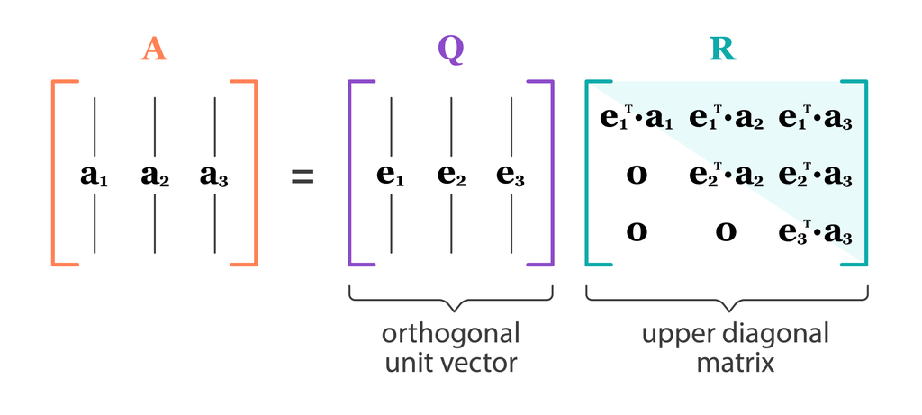

Source: https://dsc-spidal.github.io/harp/docs/harpdaal/algorithms/

### Classical Gram-Schmidt

```r
cgs <- function(X) {  # not in-place
    n <- dim(X)[1]
    p <- dim(X)[2]
    Q <- Matrix(0, nrow=n, ncol=p, sparse=FALSE)
    R <- Matrix(0, nrow=p, ncol=p, sparse=FALSE)
    for (k in seq_len(p)) {
        Q[, k] <- X[, k]
        for (j in seq_len(k-1)) {
            R[j, k] = sum(Q[, j] * X[, k])  # dot product
            Q[, k] <- Q[, k] - R[j, k] * Q[, j]
        }
        R[k, k] <- Matrix::norm(Q[, k, drop=FALSE], "F")
        Q[, k] <- Q[, k] / R[k, k]
    }
    list(Q=Q, R=R)
}
```

- CGS is *unstable* (we lose orthogonality due to roundoff errors) when columns of $\mathbf{X}$ are almost collinear.

```r
e <- .Machine$double.eps
(A <- t(Matrix(c(1, 1, 1, e, 0, 0, 0, e, 0, 0, 0, e), nrow=3)))
```

**Code Output**

```
4 x 3 Matrix of class "dgeMatrix"
             [,1]         [,2]         [,3]
[1,] 1.000000e+00 1.000000e+00 1.000000e+00
[2,] 2.220446e-16 0.000000e+00 0.000000e+00
[3,] 0.000000e+00 2.220446e-16 0.000000e+00
[4,] 0.000000e+00 0.000000e+00 2.220446e-16
```

```r
res <- cgs(A)
res$Q
```

**Code Output**

```
4 x 3 Matrix of class "dgeMatrix"
             [,1]       [,2]       [,3]
[1,] 1.000000e+00  0.0000000  0.0000000
[2,] 2.220446e-16 -0.7071068 -0.7071068
[3,] 0.000000e+00  0.7071068  0.0000000
[4,] 0.000000e+00  0.0000000  0.7071068
```

```r
with(res, t(Q) %*% Q)
```

**Code Output**

```
3 x 3 Matrix of class "dgeMatrix"
              [,1]          [,2]          [,3]
[1,]  1.000000e+00 -1.570092e-16 -1.570092e-16
[2,] -1.570092e-16  1.000000e+00  5.000000e-01
[3,] -1.570092e-16  5.000000e-01  1.000000e+00
```

- `Q` is hardly orthogonal.
- Where exactly does the problem occur? (HW)

### Modified Gram-Schmidt

- The algorithm:
  0. Initialize $\mathbf{q}_1 = \mathbf{x}_1 / \|\mathbf{x}_1\|_2$
  1. For $k=2, \ldots, p$,
     $$\begin{eqnarray*}
     \mathbf{v}_k &=& \mathbf{x}_k - P_{\text{span}(\{\mathbf{q}_1,\ldots,\mathbf{q}_{k-1}\})}(\mathbf{x}_k) = \mathbf{x}_k - \sum_{j=1}^{k-1} \langle \mathbf{q}_j, \mathbf{x}_k \rangle \cdot \mathbf{q}_j \\
     &=& \mathbf{x}_k - \sum_{j=1}^{k-1} \left\langle \mathbf{q}_j, \mathbf{x}_k - \sum_{l=1}^{j-1}\langle \mathbf{q}_l, \mathbf{x}_k \rangle \mathbf{q}_l \right\rangle \cdot \mathbf{q}_j \\
     \mathbf{q}_k &=& \mathbf{v}_k / \|\mathbf{v}_k\|_2
     \end{eqnarray*}$$

```r
mgs <- function(X) { #  in-place
    n <- dim(X)[1]
    p <- dim(X)[2]
    R <- Matrix(0, nrow=p, ncol=p)
    for (k in seq_len(p)) {
        for (j in seq_len(k-1)) {
            R[j, k] <- sum(X[, j] * X[, k])  # dot product
            X[, k] <- X[, k] - R[j, k] * X[, j]
        }
        R[k, k] <- Matrix::norm(X[, k, drop=FALSE], "F")
        X[, k] <- X[, k] / R[k, k]
    }
    list(Q=X, R=R)
}
```

- $\mathbf{X}$ is overwritten by $\mathbf{Q}$ and $\mathbf{R}$ is stored in a separate array.

```r
mres <- mgs(A)
mres$Q
```

**Code Output**

```
4 x 3 Matrix of class "dgeMatrix"
             [,1]       [,2]       [,3]
[1,] 1.000000e+00  0.0000000  0.0000000
[2,] 2.220446e-16 -0.7071068 -0.4082483
[3,] 0.000000e+00  0.7071068 -0.4082483
[4,] 0.000000e+00  0.0000000  0.8164966
```

```r
with(mres, t(Q) %*% Q)
```

**Code Output**

```
3 x 3 Matrix of class "dgeMatrix"
              [,1]          [,2]          [,3]
[1,]  1.000000e+00 -1.570092e-16 -9.064933e-17
[2,] -1.570092e-16  1.000000e+00  1.030189e-16
[3,] -9.064933e-17  1.030189e-16  1.000000e+00
```

- So MGS is more stable than CGS. However, even MGS is not completely immune to instability.

```r
(B <- t(Matrix(c(0.7, 1/sqrt(2), 0.7 + e, 1/sqrt(2)), nrow=2)))
```

**Code Output**

```
2 x 2 Matrix of class "dgeMatrix"
     [,1]      [,2]
[1,]  0.7 0.7071068
[2,]  0.7 0.7071068
```

```r
mres2 <- mgs(B)
mres2$Q
```

**Code Output**

```
2 x 2 Matrix of class "dgeMatrix"
          [,1] [,2]
[1,] 0.7071068    1
[2,] 0.7071068    0
```

```r
with(mres2, t(Q) %*% Q)
```

**Code Output**

```
2 x 2 Matrix of class "dgeMatrix"
          [,1]      [,2]
[1,] 1.0000000 0.7071068
[2,] 0.7071068 1.0000000
```

- `Q` is hardly orthogonal.
- Where exactly does the problem occur? (HW)
- Computational cost of CGS and MGS is $\sum_{k=1}^p 4n(k-1) \approx 2np^2$.
- There are 3 algorithms to compute QR: (modified) Gram-Schmidt, Householder transform, (fast) Givens transform.

  In particular, the **Householder transform** for QR is implemented in LAPACK and thus used in R, Matlab, and Julia.

## QR by Householder transform

[figure not shown]

[Alston Scott Householder (1904-1993)](https://en.wikipedia.org/wiki/Alston_Scott_Householder)

- **This is the algorithm for solving linear regression in R**.
- Assume again $\mathbf{X} = [\mathbf{x}_1 | \dotsb | \mathbf{x}_p] \in \mathbb{R}^{n \times p}$ has full column rank.
- Gram-Schmidt can be understood as:
  $$\mathbf{X}\mathbf{R}_{1} \mathbf{R}_2 \cdots \mathbf{R}_n = \mathbf{Q}_1$$
  where $\mathbf{R}_j$ are a sequence of upper triangular matrices.
- Householder QR does
  $$\mathbf{H}_{p} \cdots \mathbf{H}_2 \mathbf{H}_1 \mathbf{X} = \begin{pmatrix} \mathbf{R}_1 \\ \mathbf{0} \end{pmatrix},$$
  where $\mathbf{H}_j \in \mathbf{R}^{n \times n}$ are a sequence of Householder transformation matrices.

  It yields the **full QR** where $\mathbf{Q} = \mathbf{H}_1 \cdots \mathbf{H}_p \in \mathbb{R}^{n \times n}$. Recall that CGS/MGS only produces the **reduced QR** decomposition.
- For arbitrary $\mathbf{x}, \mathbf{w} \in \mathbb{R}^{n}$ with $\|\mathbf{x}\|_2 = \|\mathbf{w}\|_2$, we can construct a **Householder matrix** (or **Householder reflector**)
  $$\mathbf{H} = \mathbf{I}_n - 2 \mathbf{u} \mathbf{u}^T, \quad \mathbf{u} = - \frac{1}{\|\mathbf{x} - \mathbf{w}\|_2} (\mathbf{x} - \mathbf{w}),$$
  that transforms $\mathbf{x}$ to $\mathbf{w}$:
  $$\mathbf{H} \mathbf{x} = \mathbf{w}.$$
  To see this, note $\mathbf{u}^T\mathbf{x} = - (\mathbf{x}^T\mathbf{x} - \mathbf{w}^T\mathbf{x})/\Vert \mathbf{x} - \mathbf{w} \Vert_2$. Then
  $$\begin{split}
  \mathbf{H}\mathbf{x} &= \mathbf{x} + \frac{2(\mathbf{x}^T\mathbf{x} - \mathbf{w}^T\mathbf{x})}{\Vert \mathbf{x} - \mathbf{w} \Vert_2}\mathbf{u}
  = \mathbf{x} - \frac{2(\mathbf{x}^T\mathbf{x} - \mathbf{w}^T\mathbf{x})}{\Vert \mathbf{x} - \mathbf{w} \Vert_2}\frac{\mathbf{x} - \mathbf{w}}{\Vert \mathbf{x} - \mathbf{w} \Vert_2}
  \\
  &=
  \frac{(\Vert\mathbf{x} - \mathbf{w}\Vert_2^2 - 2\mathbf{x}^T\mathbf{x} + 2\mathbf{w}^T\mathbf{x})\mathbf{x} + 2(\mathbf{x}^T\mathbf{x} - \mathbf{w}^T\mathbf{x})\mathbf{w}}{\Vert \mathbf{x} - \mathbf{w} \Vert_2^2}
  \\
  &=
  \frac{(\mathbf{x}^T\mathbf{x} + \mathbf{w}^T\mathbf{w} - 2\mathbf{w}^T\mathbf{x} - 2\mathbf{x}^T\mathbf{x} + 2\mathbf{w}^T\mathbf{x})\mathbf{x} + 2(\mathbf{x}^T\mathbf{x} - \mathbf{w}^T\mathbf{x})\mathbf{w}}{\Vert \mathbf{x} - \mathbf{w} \Vert_2^2}
  \\
  &=
  \frac{(\mathbf{x}^T\mathbf{x} + \mathbf{w}^T\mathbf{w} - 2\mathbf{w}^T\mathbf{x})\mathbf{w}}{\Vert \mathbf{x} - \mathbf{w} \Vert_2^2}
  \\
  &= \frac{\Vert \mathbf{x} - \mathbf{w} \Vert_2^2\mathbf{w}}{\Vert \mathbf{x} - \mathbf{w} \Vert_2^2}
  = \mathbf{w}
  \end{split}$$
  using $\mathbf{x}^T\mathbf{x} = \mathbf{w}^T\mathbf{w}$.

$\mathbf{H}$ is symmetric and orthogonal. Calculation of Householder vector $\mathbf{u}$ costs $3n$ flops for general $\mathbf{u}$ and $\mathbf{w}$.

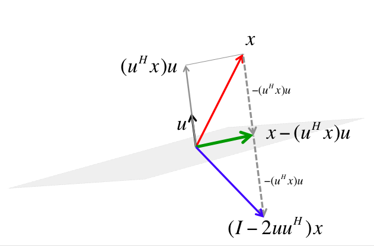

Source: https://www.cs.utexas.edu/users/flame/laff/alaff/images/Chapter03/reflector.png

- Now choose $\mathbf{H}_1$ so that
  $$\mathbf{H}_1 \mathbf{x}_1 = \begin{pmatrix} \pm\|\mathbf{x}_{1}\|_2 \\ 0 \\ \vdots \\ 0 \end{pmatrix}.$$
  That is, $\mathbf{x} = \mathbf{x}_1$ and $\mathbf{w} = \pm\|\mathbf{x}_1\|_2\mathbf{e}_1$.
- Left-multiplying $\mathbf{H}_1$ zeros out the first column of $\mathbf{X}$ below (1, 1):
  $$\mathbf{H}_1\mathbf{X} =
  \begin{bmatrix}
  \times & \times & \times & \times \\
  0 & \times & \times & \times \\
  0 & \times & \times & \times \\
  0 & \times & \times & \times \\
  0 & \times & \times & \times
  \end{bmatrix}$$
- Take $\mathbf{H}_2$ to zero the second column below diagonal:
  $$\mathbf{H}_2\mathbf{H}_1\mathbf{X} =
  \begin{bmatrix}
  \times & \times & \times & \times \\
  0 & \boldsymbol{\times} & \boldsymbol{\times} & \boldsymbol{\times} \\
  0 & \mathbf{0} & \boldsymbol{\times} & \boldsymbol{\times} \\
  0 & \mathbf{0} & \boldsymbol{\times} & \boldsymbol{\times} \\
  0 & \mathbf{0} & \boldsymbol{\times} & \boldsymbol{\times}
  \end{bmatrix}$$
- In general, choose the $j$-th Householder transform $\mathbf{H}_j = \mathbf{I}_n - 2 \mathbf{u}_j \mathbf{u}_j^T$, where
  $$\mathbf{u}_j = \begin{bmatrix} \mathbf{0}_{j-1} \\ {\tilde u}_j \end{bmatrix}, \quad {\tilde u}_j \in \mathbb{R}^{n-j+1},$$
  to zero the $j$-th column below diagonal. $\mathbf{H}_j$ takes the form
  $$\mathbf{H}_j = \begin{bmatrix}
  \mathbf{I}_{j-1} & \\
  & \mathbf{I}_{n-j+1} - 2 {\tilde u}_j {\tilde u}_j^T
  \end{bmatrix} = \begin{bmatrix}
  \mathbf{I}_{j-1} & \\
  & {\tilde H}_{j}
  \end{bmatrix}.$$
- Applying a Householder transform $\mathbf{H} = \mathbf{I} - 2 \mathbf{u} \mathbf{u}^T$ to a matrix $\mathbf{X} \in \mathbb{R}^{n \times p}$
  $$\mathbf{H} \mathbf{X} = \mathbf{X} - 2 \mathbf{u} (\mathbf{u}^T \mathbf{X})$$
  costs $4np$ flops. **Householder updates never entails explicit formation of the Householder matrices.**
- Note applying ${\tilde H}_j$ to $\mathbf{X}$ only needs $4(n-j+1)(p-j+1)$ flops.

### Algorithm

```r
for (j in seq_len(p)) {  # in-place
    u <- Householer(X[j:n, j])
    for (i in j:p)
        X[j:n, i] <- X[j:n, i] - 2 * u * sum(u * X[j:n, i])
    }
}
```

- The process is done in place. Upper triangular part of $\mathbf{X}$ is overwritten by $\mathbf{R}_1$ and the essential Householder vectors ($\tilde u_{j1}$ is normalized to 1) are stored in $\mathbf{X}[j:n,j]$. Can ensure $u_{j1} \neq 0$ by a clever choice of the sign in determining vector $\mathbf{w}$ above (HW).
- At $j$-th stage
  0. computing the Householder vector ${\tilde u}_j$ costs $3(n-j+1)$ flops
  1. applying the Householder transform ${\tilde H}_j$ to the $\mathbf{X}[j:n, j:p]$ block costs $4(n-j+1)(p-j+1)$ flops
- In total we need $\sum_{j=1}^p [3(n-j+1) + 4(n-j+1)(p-j+1)] \approx 2np^2 - \frac 23 p^3$ flops.
- Where is $\mathbf{Q}$?
  - $\mathbf{Q} = \mathbf{H}_1 \cdots \mathbf{H}_p$. In some applications, it’s necessary to form the orthogonal matrix $\mathbf{Q}$.

  Accumulating $\mathbf{Q}$ costs another $2np^2 - \frac 23 p^3$ flops.
- When computing $\mathbf{Q}^T \mathbf{v}$ or $\mathbf{Q} \mathbf{v}$ as in some applications (e.g., solve linear equation using QR), no need to form $\mathbf{Q}$. Simply apply Householder transforms successively to the vector $\mathbf{v}$. (HW)
- Computational cost of Householder QR for linear regression: $2n p^2 - \frac 23 p^3$ (regression coefficients and $\hat \sigma^2$) or more (fitted values, s.e., …).

### Implementation

- R function: [`qr`](https://stat.ethz.ch/R-manual/R-devel/library/base/html/qr.html)
- Wraps LAPACK routine [`dgeqp3`](http://www.netlib.org/lapack/explore-html/dd/d9a/group__double_g_ecomputational_ga1b0500f49e03d2771b797c6e88adabbb.html) (with `LAPACK=TRUE`; default uses LINPACK, an ancient version of LAPACK).

```r
X  # to recall
```

**Code Output**

```
           [,1]       [,2]       [,3]
[1,]  0.3769721  0.7205735 -0.8531228
[2,]  0.3015484  0.9391210  0.9092592
[3,] -1.0980232 -0.2293777  1.1963730
[4,] -1.1304059  1.7591313 -0.3715839
[5,] -2.7965343  0.1173668 -0.1232602
```

```r
y
```

**Code Output**

```
[1]  1.80004312  1.70399588 -3.03876461 -2.28897495  0.05830349
```

```r
coef(lm(y ~ X - 1)) # least squares solution by QR
```

**Code Output**

```
          X1           X2           X3
 0.615117664 -0.008382116 -0.770116370
```

```r
# same as
qr.solve(X, y)  # or solve(qr(X), y)
```

**Code Output**

```
[1]  0.615117664 -0.008382116 -0.770116370
```

```r
(qrobj <- qr(X, LAPACK=TRUE))
```

**Code Output**

```
$qr
           [,1]        [,2]       [,3]
[1,] -3.2460924  0.46519442  0.1837043
[2,]  0.0832302 -2.08463446  0.3784090
[3,] -0.3030648 -0.05061826 -1.7211061
[4,] -0.3120027  0.61242637 -0.4073016
[5,] -0.7718699  0.10474144 -0.3750994

$rank
[1] 3

$qraux
[1] 1.116131 1.440301 1.530697

$pivot
[1] 1 2 3

attr(,"useLAPACK")
[1] TRUE
attr(,"class")
[1] "qr"
```

The upper triangular part of `qrobj$qr` contains the $\mathbf{R}$ of the decomposition and the lower triangular part contains information on the $\mathbf{Q}$ of the decomposition (stored in compact form using $\mathbf{Q} = \mathbf{H}_1 \cdots \mathbf{H}_p$, HW).

```r
qr.Q(qrobj)  # extract Q
```

**Code Output**

```
            [,1]       [,2]        [,3]
[1,] -0.11613105 -0.3715745  0.40159171
[2,] -0.09289581 -0.4712268 -0.64182039
[3,]  0.33825998  0.1855167 -0.61822569
[4,]  0.34823590 -0.7661458  0.08461993
[5,]  0.86150792  0.1359480  0.19346097
```

```r
qr.R(qrobj) # extract R
```

**Code Output**

```
          [,1]       [,2]       [,3]
[1,] -3.246092  0.4651944  0.1837043
[2,]  0.000000 -2.0846345  0.3784090
[3,]  0.000000  0.0000000 -1.7211061
```

```r
qr.qty(qrobj, y)  # this uses the "compact form"
```

**Code Output**

```
           [,1]
[1,] -2.1421018
[2,] -0.2739453
[3,]  1.3254520
[4,] -3.3263425
[5,]  1.7707709
```

```r
t(qr.Q(qrobj)) %*% y  # waste of resource
```

**Code Output**

```
           [,1]
[1,] -2.1421018
[2,] -0.2739453
[3,]  1.3254520
```

```r
solve(qr.R(qrobj), qr.qty(qrobj, y)[1:p])  # solves R * beta = Q' * y
```

**Code Output**

```
[1]  0.615117664 -0.008382116 -0.770116370
```

```r
Xchol <- Matrix::chol(Matrix::symmpart(t(X) %*% X))  # solution using Cholesky of X'X
solve(Xchol, solve(t(Xchol), t(X) %*% y))
```

**Code Output**

```
             [,1]
[1,]  0.615117664
[2,] -0.008382116
[3,] -0.770116370
```

Lets get back to the odd `A` and `B` matrices that fooled Gram-Schmidt.

```r
qrA <- qr(A, LAPACK=TRUE)
qr.Q(qrA)
```

**Code Output**

```
              [,1]          [,2]          [,3]
[1,] -1.000000e+00  1.570092e-16  9.064933e-17
[2,] -2.220446e-16 -7.071068e-01 -4.082483e-01
[3,]  0.000000e+00  7.071068e-01 -4.082483e-01
[4,]  0.000000e+00  0.000000e+00  8.164966e-01
```

```r
t(qr.Q(qrA)) %*% qr.Q(qrA)   # orthogonality preserved
```

**Code Output**

```
     [,1]          [,2]          [,3]
[1,]    1  0.000000e+00  0.000000e+00
[2,]    0  1.000000e+00 -1.027669e-16
[3,]    0 -1.027669e-16  1.000000e+00
```

```r
qrB <- qr(B, LAPACK=TRUE)
qr.Q(qrB)
```

**Code Output**

```
           [,1]       [,2]
[1,] -0.7071068 -0.7071068
[2,] -0.7071068  0.7071068
```

```r
t(qr.Q(qrB)) %*% qr.Q(qrB)  # orthogonality preserved
```

**Code Output**

```
              [,1]          [,2]
[1,]  1.000000e+00 -1.008758e-16
[2,] -1.008758e-16  1.000000e+00
```

## QR by Givens rotation

- Householder transform $\mathbf{H}_j$ introduces batch of zeros into a vector.
- **Givens transform** (aka **Givens rotation**, **Jacobi rotation**, **plane rotation**) selectively zeros one element of a vector.
- Overall QR by Givens rotation is less efficient than the Householder method, but is better suited for matrices with structured patterns of nonzero elements.
- **Givens/Jacobi rotations**:
  $$\mathbf{G}(i,k,\theta) = \begin{bmatrix}
  1 & & 0 & & 0 & & 0 \\
  \vdots & \ddots & \vdots & & \vdots & & \vdots \\
  0 & & c & & s & & 0 \\
  \vdots & & \vdots & \ddots & \vdots & & \vdots \\
  0 & & - s & & c & & 0 \\
  \vdots & & \vdots & & \vdots & \ddots & \vdots \\
  0 & & 0 & & 0 & & 1 \end{bmatrix},$$
  where $c = \cos(\theta)$ and $s = \sin(\theta)$. $\mathbf{G}(i,k,\theta)$ is orthogonal.
- Pre-multiplication by $\mathbf{G}(i,k,\theta)^T$ rotates counterclockwise $\theta$ radians in the $(i,k)$ coordinate plane. If $\mathbf{x} \in \mathbb{R}^n$ and $\mathbf{y} = \mathbf{G}(i,k,\theta)^T \mathbf{x}$, then
  $$y_j = \begin{cases}
  cx_i - s x_k & j = i \\
  sx_i + cx_k & j = k \\
  x_j & j \ne i, k
  \end{cases}.$$
  Apparently if we choose $\tan(\theta) = -x_k / x_i$, or equivalently,
  $$\begin{eqnarray*}
  c = \frac{x_i}{\sqrt{x_i^2 + x_k^2}}, \quad s = \frac{-x_k}{\sqrt{x_i^2 + x_k^2}},
  \end{eqnarray*}$$
  then $y_k=0$.
- Pre-applying Givens transform $\mathbf{G}(i,k,\theta)^T \in \mathbb{R}^{n \times n}$ to a matrix $\mathbf{A} \in \mathbb{R}^{n \times m}$ only effects two rows of $\mathbf{ A}$:
  $$\mathbf{A}([i, k], :) \gets \begin{bmatrix} c & s \\ -s & c \end{bmatrix}^T \mathbf{A}([i, k], :),$$
  costing $6m$ flops.
- Post-applying Givens transform $\mathbf{G}(i,k,\theta) \in \mathbb{R}^{m \times m}$ to a matrix $\mathbf{A} \in \mathbb{R}^{n \times m}$ only effects two columns of $\mathbf{A}$:
  $$\mathbf{A}(:, [i,k]) \gets \mathbf{A}(:, [i,k]) \begin{bmatrix} c & s \\ -s & c \end{bmatrix},$$
  costing $6n$ flops.
- QR by Givens: $\mathbf{G}_t^T \cdots \mathbf{G}_1^T \mathbf{X} = \begin{bmatrix} \mathbf{R}_1 \\ \mathbf{0} \end{bmatrix}$.

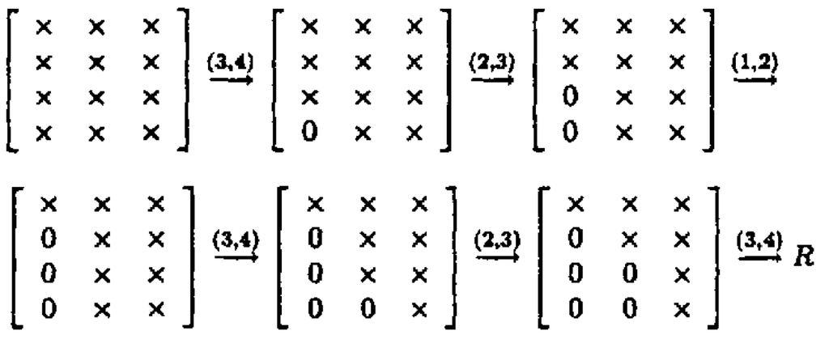

- Zeros in $\mathbf{X}$ can also be introduced row-by-row.
- If $\mathbf{X} \in \mathbb{R}^{n \times p}$, the total cost is $3np^2 - p^3$ flops and $O(np)$ square roots.
- Note each Givens transform can be summarized by a single number, which is stored in the zeroed entry of $\mathbf{X}$.

# Conditioning of linear regression by least squares

- Recall that for nonsingular linear equation solve, i.e. $\mathbf{A}\mathbf{x} = \mathbf{b}$, the condition number of the problem with $\mathbf{b}$ held fixed is equal to the condition number of matrix $\mathbf{A}$
  $$\kappa(\mathbf{A}) = \sigma_{\max}(\mathbf{A})/\sigma_{\min}(\mathbf{A}) = \sigma_{\max}(\mathbf{A})\sigma_{\max}(\mathbf{A}^{-1}). % \|\mathbf{A}\|\|\mathbf{A}^{-1}\|.$$
- If $\mathbf{A}$ is not square, then its condition number is
  $$\kappa(\mathbf{A}) = \sigma_{\max}(\mathbf{A})\sigma_{\max}(\mathbf{A}^{\dagger})=\sigma_{\max}(\mathbf{A})/\sigma_{\min}(\mathbf{A}), %\|\mathbf{A}\|\|\mathbf{A}^{\dagger}\|,$$
  where $\mathbf{A}^{\dagger}$ is Moore-Penrose pseudoinverse of $\mathbf{A}$.
- **Condition number for the least squares problem** $\mathbf{y} \approx \mathbf{X}\boldsymbol{\beta}$ is more complicated and depends on the residual. It can be shown that the condition number is
  $$\kappa(\mathbf{X}) + \frac{\kappa(\mathbf{X})^2\tan\theta}{\eta},$$
  where

$$\theta = \cos^{-1}\frac{\|\mathbf{X}\boldsymbol{\beta}\|}{\|\boldsymbol{\beta}\|},
\quad
\eta = \frac{\|\mathbf{X}\|\|\boldsymbol{\beta}\|}{\|\mathbf{X}\boldsymbol{\beta}\|}
.$$

- So if $\kappa(\mathbf{X})$ is large ($\mathbf{X}$ is close to collinear), the condition number of the least squares problem is dominated by $\kappa(\mathbf{X})^2$, unless the residuals are small.
  - In this case, *stable* algorithm is preferred.
- This is because the problem is equivalent to the normal equation
  $$\mathbf{X}^T\mathbf{X}\boldsymbol{\beta} = \mathbf{X}^T\mathbf{y}.$$
- Consider the simple case
  $$\begin{eqnarray*}
  \mathbf{X} = \begin{bmatrix}
  1 & 1 \\
  10^{-3} & 0 \\
  0 & 10^{-3}
  \end{bmatrix}.
  \end{eqnarray*}$$
  Forming normal equation yields a singular Gramian matrix
  $$\begin{eqnarray*}
  \mathbf{X}^T \mathbf{X} = \begin{bmatrix}
  1 & 1 \\
  1 & 1
  \end{bmatrix}
  \end{eqnarray*}$$
  if executed with a precision of 6 decimal digits. This has the condition number $\kappa(\mathbf{X}^T\mathbf{X})=\infty$.

# Summary of linear regression

Methods for solving linear regression $\widehat \beta = (\mathbf{X}^T \mathbf{X})^{-1} \mathbf{X}^T \mathbf{y}$:

| Method | Flops | Remarks | Software | Stability |
| --- | --- | --- | --- | --- |
| Cholesky | $np^2 + p^3/3$ |  |  | unstable |
| QR by Householder | $2np^2 - (2/3)p^3$ |  | R, Julia, MATLAB | stable |
| QR by MGS | $2np^2$ | $Q_1$ available |  | stable |
| QR by SVD | $4n^2p + 8np^2 + 9p^3$ | $X = UDV^T$ |  | most stable |

Remarks:

1. When $n \gg p$, Cholesky is twice faster than QR and need less space.
2. Cholesky is based on the **Gram matrix** $\mathbf{X}^T \mathbf{X}$, which can be dynamically updated with incoming data. They can handle huge $n$, moderate $p$ data sets that cannot fit into memory.
3. QR methods are more stable and produce numerically more accurate solution.
4. MGS appears slower than Householder, but it yields $\mathbf{Q}_1$.

> **There is simply no such thing as a universal ‘gold standard’ when it comes to algorithms.**

## Underdetermined least squares

- When the Gram matrix $\mathbf{X}^T\mathbf{X}$ is singular (this happens if $\text{rank}(\mathbf{X})<p$, in particular $n < p$), the normal equation $\mathbf{X}^T\mathbf{X}\boldsymbol{\beta} = \mathbf{X}^T\mathbf{y}$ is *underdetermined*.
- It has *many* solutions unless an additional condition is added.
- Typically we require solution $\boldsymbol{\beta}$ has a smallest norm; the solution depends on the choice of the norm.
- Example: minimum $\ell_2$ norm solution
  $$\text{minimize}~\|\boldsymbol{\beta}\|_2 ~\text{subject to}~\mathbf{X}^T\mathbf{X}\boldsymbol{\beta} = \mathbf{X}^T\mathbf{y}$$
  - Solution is closed form: $\hat{\boldsymbol{\beta}} = \mathbf{X}^{\dagger}\mathbf{y}$, where $\mathbf{X}^{\dagger}$ is the Moore-Penrose pseudoinverse of $\mathbf{X}$: $\mathbf{X}^{\dagger} = \mathbf{X}^T(\mathbf{X}\mathbf{X}^T)^{-1}$ if $n<p$ and $\mathbf{X}$ has full row rank.
  - In fact $\hat{\boldsymbol{\beta}}$ is a limit of the ridge regression: $\hat{\boldsymbol{\beta}} = \lim_{\lambda\to 0}(\mathbf{X}^T\mathbf{X}+\lambda\mathbf{I})^{-1}\mathbf{X}^T\mathbf{y}$.
- Example: minimum $\ell_0$ “norm” solution
  $$\text{minimize}~\|\boldsymbol{\beta}\|_0 ~\text{subject to}~\mathbf{X}^T\mathbf{X}\boldsymbol{\beta} = \mathbf{X}^T\mathbf{y}$$
  - $\|\boldsymbol{\beta}\|_0 \triangleq \sum_{i=1}^p \mathbf{1}_{\{\beta_i\neq 0\}}$, the “sparsest” solution.
  - Model selection problem. Combinatorial (intractable if $p$ large).
- Compromise: minimum $\ell_1$ norm solution
  $$\text{minimize}~\|\boldsymbol{\beta}\|_1 ~\text{subject to}~\mathbf{X}^T\mathbf{X}\boldsymbol{\beta} = \mathbf{X}^T\mathbf{y}$$
  - LASSO.
  - Convex optimization problem (linear programming). Tractable.
  - Under certain conditions recovers the minimum $\ell_0$ norm solution.